# Chapter 6 Lab 2

```r
library(ISLR)
attach(Hitters)

Hitters = na.omit(Hitters)
```

To use `glmnet()` for ridge and lasso, we must:

- Pass in an `x` matrix
- Pass in a `y` vector
- Do not use the `y ~ x` syntax

```r
x = model.matrix(Salary ~ .,
                 Hitters)[, -1]

dim(x)
```

```
[1] 263  19
```

```r
y = Hitters$Salary
```

## 6.6.1 - Ridge Regression

`glmnet()` has an `alpha` argument:

- `alpha = 0`, ridge
- `alpha = 1`, lasso

Note that by default, `glmnet()` **standardizes** the variables. To turn off, set `standardize = FALSE`. This is why we need to make sure there’s no missing value in the dataset.

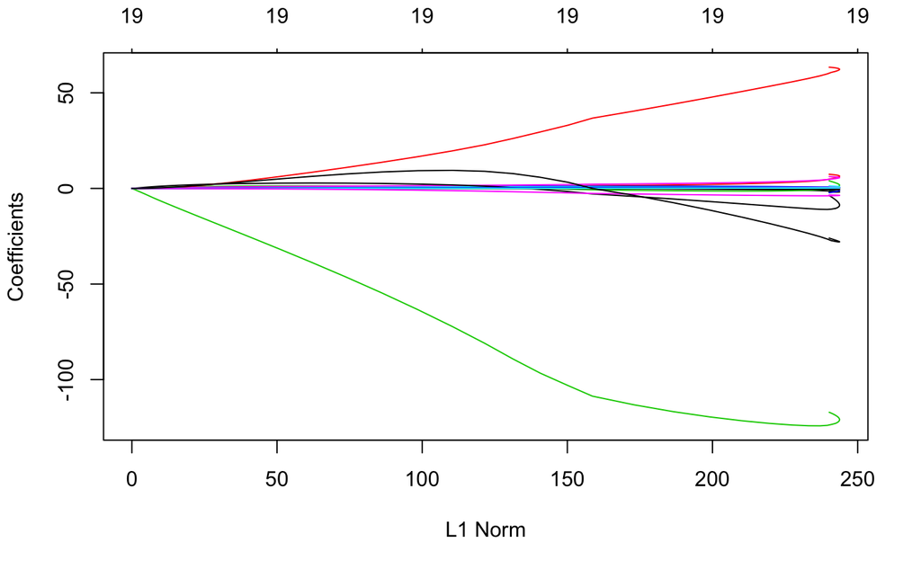

```r
library(glmnet)
grid = 10 ^ seq(10,-2, length = 100) # Range of equal distance lambda values from 10^10 to 10^-2

ridge.mod = glmnet(x, y, alpha = 0, lambda = grid)

plot(ridge.mod)
```

`coef()` returns the coefficient grid, with each row corresponding to a predictor and each column corresponding to an $\lambda$.

```r
dim(coef(ridge.mod))
```

```
[1]  20 100
```

```r
coef(ridge.mod)[1:20, 1:5]
```

```
20 x 5 sparse Matrix of class "dgCMatrix"
                       s0            s1            s2            s3            s4
(Intercept)  5.359257e+02  5.359256e+02  5.359256e+02  5.359254e+02  5.359253e+02
AtBat        5.443467e-08  7.195940e-08  9.512609e-08  1.257511e-07  1.662355e-07
Hits         1.974589e-07  2.610289e-07  3.450649e-07  4.561554e-07  6.030105e-07
HmRun        7.956523e-07  1.051805e-06  1.390424e-06  1.838059e-06  2.429805e-06
Runs         3.339178e-07  4.414196e-07  5.835307e-07  7.713931e-07  1.019736e-06
RBI          3.527222e-07  4.662778e-07  6.163918e-07  8.148335e-07  1.077162e-06
Walks        4.151323e-07  5.487803e-07  7.254552e-07  9.590089e-07  1.267753e-06
Years        1.697711e-06  2.244274e-06  2.966798e-06  3.921931e-06  5.184561e-06
CAtBat       4.673743e-09  6.178412e-09  8.167496e-09  1.079695e-08  1.427293e-08
CHits        1.720071e-08  2.273832e-08  3.005872e-08  3.973585e-08  5.252844e-08
CHmRun       1.297171e-07  1.714783e-07  2.266842e-07  2.996631e-07  3.961369e-07
CRuns        3.450846e-08  4.561814e-08  6.030449e-08  7.971898e-08  1.053838e-07
CRBI         3.561348e-08  4.707892e-08  6.223556e-08  8.227173e-08  1.087584e-07
CWalks       3.767877e-08  4.980911e-08  6.584471e-08  8.704281e-08  1.150654e-07
LeagueN     -5.800263e-07 -7.667601e-07 -1.013611e-06 -1.339933e-06 -1.771310e-06
DivisionW   -7.807263e-06 -1.032074e-05 -1.364341e-05 -1.803579e-05 -2.384225e-05
PutOuts      2.180288e-08  2.882212e-08  3.810115e-08  5.036747e-08  6.658282e-08
Assists      3.561198e-09  4.707694e-09  6.223294e-09  8.226828e-09  1.087538e-08
Errors      -1.660460e-08 -2.195031e-08 -2.901702e-08 -3.835881e-08 -5.070811e-08
NewLeagueN  -1.152288e-07 -1.523253e-07 -2.013646e-07 -2.661912e-07 -3.518874e-07
```

Let’s verify that, when $\lambda$ is large, the coefficient estimates are small.

```r
ridge.mod$lambda[50]
```

```
[1] 11497.57
```

```r
coef(ridge.mod)[, 50]
```

```
  (Intercept)         AtBat          Hits         HmRun          Runs           RBI         Walks
407.356050200   0.036957182   0.138180344   0.524629976   0.230701523   0.239841459   0.289618741
        Years        CAtBat         CHits        CHmRun         CRuns          CRBI        CWalks
  1.107702929   0.003131815   0.011653637   0.087545670   0.023379882   0.024138320   0.025015421
      LeagueN     DivisionW       PutOuts       Assists        Errors    NewLeagueN
  0.085028114  -6.215440973   0.016482577   0.002612988  -0.020502690   0.301433531
```

Compute the $l_2$ norm.

```r
sqrt(sum(coef(ridge.mod)[-1, 50] ^ 2))
```

```
[1] 6.360612
```

Let’s verify that, when $\lambda$ is small, the coefficient estimates are not small.

```r
ridge.mod$lambda[75]
```

```
[1] 10.72267
```

```r
coef(ridge.mod)[, 75]
```

```
  (Intercept)         AtBat          Hits         HmRun          Runs           RBI         Walks
 121.03941275   -1.17121685    4.16555335   -0.67027625    0.50301494    0.45074152    4.34665150
        Years        CAtBat         CHits        CHmRun         CRuns          CRBI        CWalks
 -10.91561927   -0.02154818    0.17263636    0.74497092    0.46162220    0.30888439   -0.45438108
      LeagueN     DivisionW       PutOuts       Assists        Errors    NewLeagueN
  58.89440480 -124.17545130    0.27401855    0.23373456   -3.85516497  -25.24429108
```

Compute the $l_2$ norm.

```r
sqrt(sum(coef(ridge.mod)[-1, 75] ^ 2))
```

```
[1] 140.3536
```

We can see that **as $\lambda$ increases, $l_2$ norm decreases**.

We can even use `predict()` to get the coefficient estimates for a new value of $\lambda$.

```r
predict(ridge.mod, s = 50, type = 'coefficients')[1:20,]
```

```
  (Intercept)         AtBat          Hits         HmRun          Runs           RBI         Walks
 4.876610e+01 -3.580999e-01  1.969359e+00 -1.278248e+00  1.145892e+00  8.038292e-01  2.716186e+00
        Years        CAtBat         CHits        CHmRun         CRuns          CRBI        CWalks
-6.218319e+00  5.447837e-03  1.064895e-01  6.244860e-01  2.214985e-01  2.186914e-01 -1.500245e-01
      LeagueN     DivisionW       PutOuts       Assists        Errors    NewLeagueN
 4.592589e+01 -1.182011e+02  2.502322e-01  1.215665e-01 -3.278600e+00 -9.496680e+00
```

Now, split into training and test sets.

Use a different approach - randomly choose a subset of numbers between 1 and n, then use it as indices for the training observations.

```r
set.seed(647)

train = sample(1:nrow(x), nrow(x) / 2) # 50/50 split

length(train)
```

```
[1] 131
```

```r
train[1:20]
```

```
 [1] 157   2  88 222  44 219 132 223 119  35  55 104   7 142 198 150 183 168  45  16
```

```r
test = (-train)

y.test = y[test]
```

Fit the ridge regression model on the training set, with $\lambda$ = 4.

```r
ridge.mod = glmnet(x[train, ],
                   y[train],
                   alpha = 0,
                   lambda = grid,
                   thresh = 1e-12)

ridge.pred = predict(ridge.mod, s = 4, newx = x[test, ])

mean((ridge.pred - y.test) ^ 2)
```

```
[1] 137553.5
```

Let’s compare two things:

- If we were to fit the model with just an intercept, and
- If we use a very large value of $\lambda$

```r
mean((mean(y[train]) - y.test) ^ 2)
```

```
[1] 218699.3
```

```r
ridge.pred = predict(ridge.mod, s = 1e10, newx = x[test, ])

mean((ridge.pred - y.test) ^ 2)
```

```
[1] 218699.3
```

What about the least square method, which is essentially $\lambda$ = 0?

```r
ridge.pred = predict(
  ridge.mod,
  s = 0,
  newx = x[test,],
  exact = TRUE,
  x = x[train,],
  y = y[train]
) # Turn on `exact`, otherwise it would interpolate over the grid

mean((ridge.pred - y.test) ^ 2)
```

```
[1] 150237.3
```

```r
print("Least square:")
```

```
[1] "Least square:"
```

```r
lm(y ~ x, subset = train)
```

```
Call:
lm(formula = y ~ x, subset = train)

Coefficients:
(Intercept)       xAtBat        xHits       xHmRun        xRuns         xRBI       xWalks       xYears
  140.32626     -2.64241      9.35362     -1.85430     -4.19772      2.63043      6.66583    -12.51873
    xCAtBat       xCHits      xCHmRun       xCRuns        xCRBI      xCWalks     xLeagueN   xDivisionW
   -0.05442     -0.23948      1.69271      2.78131     -0.60050     -1.06319    230.09828    -72.34774
   xPutOuts     xAssists      xErrors  xNewLeagueN
    0.26222      0.44418     -6.34481   -164.71793
```

```r
print("Ridge: ")
```

```
[1] "Ridge: "
```

```r
predict(
  ridge.mod,
  s = 0,
  exact = TRUE,
  type = "coefficients",
  x = x[train,],
  y = y[train]
)[1:20,]
```

```
  (Intercept)         AtBat          Hits         HmRun          Runs           RBI         Walks
 140.32750779   -2.64230763    9.35302227   -1.85524266   -4.19731906    2.63074990    6.66568906
        Years        CAtBat         CHits        CHmRun         CRuns          CRBI        CWalks
 -12.51823912   -0.05446592   -0.23918000    1.69317950    2.78111645   -0.60071848   -1.06312084
      LeagueN     DivisionW       PutOuts       Assists        Errors    NewLeagueN
 230.10177355  -72.34729685    0.26221965    0.44419275   -6.34518062 -164.72203673
```

We can use cv to choose $\lambda$. There’s a built-in `cv.glmnet()` function. By default, `k` = 10.

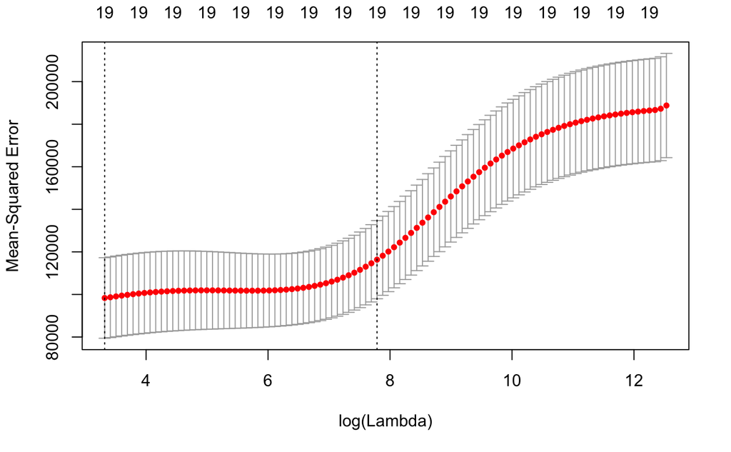

```r
set.seed(647)

cv.out = cv.glmnet(x[train,],
                   y[train],
                   alpha = 0)

plot(cv.out)
```

```r
bestlam = cv.out$lambda.min

bestlam
```

```
[1] 27.69703
```

The MSE.

```r
ridge.pred = predict(ridge.mod,
                     s = bestlam,
                     newx = x[test,])

mean((ridge.pred - y.test) ^ 2)
```

```
[1] 129654.8
```

Finally, refit the model on the full data set, using the $\lambda$ chosen by cv.

```r
out = glmnet(x, y, alpha = 0)

predict(out, type = "coefficients", s = bestlam)[1:20,]
```

```
  (Intercept)         AtBat          Hits         HmRun          Runs           RBI         Walks
 7.705876e+01 -6.379594e-01  2.658901e+00 -1.385332e+00  1.041755e+00  7.291854e-01  3.290935e+00
        Years        CAtBat         CHits        CHmRun         CRuns          CRBI        CWalks
-8.767861e+00 -4.480885e-05  1.324384e-01  6.906431e-01  2.846628e-01  2.522083e-01 -2.624266e-01
      LeagueN     DivisionW       PutOuts       Assists        Errors    NewLeagueN
 5.244981e+01 -1.224707e+02  2.625623e-01  1.638016e-01 -3.649358e+00 -1.716478e+01
```

## 6.6.2 - Lasso

Now, use `alpha` = 1 for lasso regression.

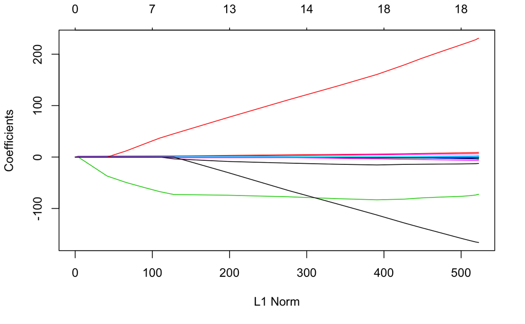

```r
lasso.mod = glmnet(x[train,],
                   y[train],
                   alpha = 1,
                   lambda = grid)

plot(lasso.mod)
```

Let’s verify that, when $\lambda$ is large, some coefficients become zero.

```r
lasso.mod$lambda[75]
```

```
[1] 10.72267
```

```r
coef(lasso.mod)[,75]
```

```
(Intercept)       AtBat        Hits       HmRun        Runs         RBI       Walks       Years
-58.2647013   0.0000000   2.1326529   0.0000000   0.0000000   0.0000000   1.8086328  -3.5442624
     CAtBat       CHits      CHmRun       CRuns        CRBI      CWalks     LeagueN   DivisionW
  0.0000000   0.0000000   0.0000000   0.7842011   0.0000000   0.0000000  45.2608366 -72.8281874
    PutOuts     Assists      Errors  NewLeagueN
  0.2249305   0.0000000  -1.1606382   0.0000000
```

```r
sqrt(sum(abs(coef(lasso.mod)[-1, 75])))
```

```
[1] 11.3024
```

Let’s verify that, when $\lambda$ is small, most coefficients are not zero.

```r
lasso.mod$lambda[80]
```

```
[1] 2.656088
```

```r
coef(lasso.mod)[,80]
```

```
  (Intercept)         AtBat          Hits         HmRun          Runs           RBI         Walks
 104.54121911   -1.79983808    6.36406512    0.93163649   -0.74913139    0.60417318    4.94435781
        Years        CAtBat         CHits        CHmRun         CRuns          CRBI        CWalks
 -14.30769386   -0.03813982    0.00000000    0.36654466    1.60785000   -0.03641218   -0.61437489
      LeagueN     DivisionW       PutOuts       Assists        Errors    NewLeagueN
 178.95138255  -81.84789350    0.24048773    0.26800483   -4.31876629 -128.03456020
```

Compute the $l_1$ norm.

```r
sqrt(sum(abs(coef(lasso.mod)[-1, 80])))
```

```
[1] 20.64038
```

We can see that **as $\lambda$ increases, $l_1$ norm also decreases (not always, but in general)**.

Now, let’s do cv on $\lambda$.

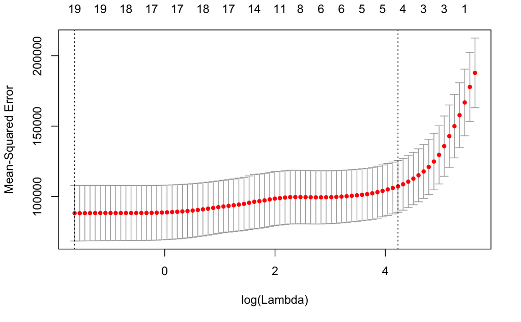

```r
set.seed(647)

cv.out = cv.glmnet(x[train,],
                   y[train],
                   alpha = 1)

plot(cv.out)
```

```r
bestlam = cv.out$lambda.min

bestlam
```

```
[1] 0.1953971
```

```r
lasso.pred = predict(lasso.mod,
                     s = bestlam,
                     newx = x[test,])

mean((lasso.pred - y.test) ^ 2)
```

```
[1] 148811.9
```

Final model.

```r
out = glmnet(x, y, alpha = 1, lambda = grid)

lasso.coef = predict(out, type = 'coefficients', s = bestlam)[1:20, ]

lasso.coef
```

```
  (Intercept)         AtBat          Hits         HmRun          Runs           RBI         Walks
 1.621161e+02 -2.008724e+00  7.457866e+00  3.386206e+00 -2.125231e+00 -6.983666e-01  6.141889e+00
        Years        CAtBat         CHits        CHmRun         CRuns          CRBI        CWalks
-4.847311e+00 -1.356052e-01  7.207366e-02 -3.283375e-03  1.392598e+00  7.195602e-01 -8.093884e-01
      LeagueN     DivisionW       PutOuts       Assists        Errors    NewLeagueN
 5.910443e+01 -1.166546e+02  2.832106e-01  3.511714e-01 -3.231016e+00 -2.147447e+01
```

Doesn’t look like any coefficient has been set to zero.